# STATS 506 Fall 2026 Homework 2

github link: https://github.com/hebe233299-source/stats506-hw2

```r
library(microbenchmark)

options(digits = 5)
```

# Problem 1

## a.

I first define the four possible directions and check that `n` is a positive integer and that `p` is between 0 and 1. The function then simulates the walk step by step and returns the final coordinates.

```r
walk_directions <- rbind(
  right = c(1, 0),
  left = c(-1, 0),
  up = c(0, 1),
  down = c(0, -1)
)

validate_walk_inputs <- function(n, p) {
  valid_n <- is.numeric(n) &&
    length(n) == 1L &&
    !is.na(n) &&
    is.finite(n) &&
    n >= 1 &&
    n == floor(n) &&
    n <= .Machine$integer.max

  if (!valid_n) {
    stop("`n` must be one finite, positive whole number.", call. = FALSE)
  }

  valid_p <- is.numeric(p) &&
    length(p) == 1L &&
    !is.na(p) &&
    is.finite(p) &&
    p >= 0 &&
    p <= 1

  if (!valid_p) {
    stop("`p` must be one finite number between 0 and 1.", call. = FALSE)
  }

  list(n = as.integer(n), p = as.numeric(p))
}
momentum_walk <- function(n, p) {
  inputs <- validate_walk_inputs(n, p)
  n <- inputs$n
  p <- inputs$p

  direction_indices <- integer(n)
  direction_indices[1] <- sample.int(4L, size = 1L)

  if (n > 1L) {
    for (step in 2:n) {
      keep_direction <- runif(1L) < p

      if (keep_direction) {
        direction_indices[step] <- direction_indices[step - 1L]
      } else {
        direction_indices[step] <- sample.int(4L, size = 1L)
      }
    }
  }

  final_position <- colSums(
    walk_directions[direction_indices, , drop = FALSE]
  )

  setNames(as.numeric(final_position), c("x", "y"))
}
```

## b.

```r
momentum_walk1 <- function(n, p) {
  inputs <- validate_walk_inputs(n, p)
  n <- inputs$n
  p <- inputs$p

  direction_indices <- integer(n)
  direction_indices[1] <- sample.int(4L, size = 1L)

  if (n > 1L) {
    for (step in 2:n) {
      keep_direction <- runif(1L) < p

      if (keep_direction) {
        direction_indices[step] <- direction_indices[step - 1L]
      } else {
        direction_indices[step] <- sample.int(4L, size = 1L)
      }
    }
  }

  final_position <- colSums(
    walk_directions[direction_indices, , drop = FALSE]
  )
  setNames(as.numeric(final_position), c("x", "y"))
}

momentum_walk2 <- function(n, p) {
  inputs <- validate_walk_inputs(n, p)
  n <- inputs$n
  p <- inputs$p

  state <- new.env(parent = emptyenv())
  first_direction <- sample.int(4L, size = 1L)
  state$direction <- first_direction

  later_directions <- unlist(
    lapply(seq_len(n - 1L), function(step) {
      if (runif(1L) >= p) {
        state$direction <- sample.int(4L, size = 1L)
      }
      state$direction
    }),
    use.names = FALSE
  )

  direction_indices <- c(first_direction, later_directions)
  final_position <- colSums(
    walk_directions[direction_indices, , drop = FALSE]
  )
  setNames(as.numeric(final_position), c("x", "y"))
}
```

For example, invalid values of n and p return the following errors.

```r
validation_evidence <- data.frame(
  invalid_input = c("n = 0", "p = 1.2"),
  error_message = c(
    tryCatch(
      momentum_walk1(0, 0.6),
      error = function(error) conditionMessage(error)
    ),
    tryCatch(
      momentum_walk2(10, 1.2),
      error = function(error) conditionMessage(error)
    )
  )
)

knitr::kable(validation_evidence)
```

| invalid_input | error_message |
| --- | --- |
| n = 0 | `n` must be one finite, positive whole number. |
| p = 1.2 | `p` must be one finite number between 0 and 1. |

```r
set.seed(50601)
momentum_walk1(10, 0.6)
```

```
 x  y
-3 -1
```

```r
momentum_walk2(10, 0.6)
```

```
 x  y
-6  2
```

```r
momentum_walk1(1000, 0.6)
```

```
  x   y
-32 -18
```

```r
momentum_walk2(1000, 0.6)
```

```
 x  y
-6 18
```

momentum_walk1() updates the direction step by step with a for loop. momentum_walk2() uses lapply() while storing the previous direction in state, so the steps are still generated sequentially. When a new direction is drawn, all four directions are possible, including the previous one. Both functions return the final (x, y) position.

## c.

```r
reproducibility_seed <- 506

set.seed(reproducibility_seed)
walk_10_first <- momentum_walk1(10, 0.6)
set.seed(reproducibility_seed)
walk_10_second <- momentum_walk1(10, 0.6)

set.seed(reproducibility_seed)
walk_1000_first <- momentum_walk1(1000, 0.6)
set.seed(reproducibility_seed)
walk_1000_second <- momentum_walk1(1000, 0.6)

reproducibility_results <- data.frame(
  n = c(10L, 1000L),
  first_x = c(walk_10_first["x"], walk_1000_first["x"]),
  first_y = c(walk_10_first["y"], walk_1000_first["y"]),
  second_x = c(walk_10_second["x"], walk_1000_second["x"]),
  second_y = c(walk_10_second["y"], walk_1000_second["y"]),
  identical = c(
    identical(walk_10_first, walk_10_second),
    identical(walk_1000_first, walk_1000_second)
  ),
  row.names = NULL
)

knitr::kable(reproducibility_results)
```

| n | first_x | first_y | second_x | second_y | identical |
| --- | --- | --- | --- | --- | --- |
| 10 | -2 | 0 | -2 | 0 | TRUE |
| 1000 | -14 | -30 | -14 | -30 | TRUE |

`set.seed(506)` places R’s pseudo-random-number generator in a known state. Resetting that state before the same sequence of random computations produces the same sequence of draws, so both repeated simulations have identical final coordinates, as shown in the last column.

## d.

```r
set.seed(50602)
momentum_values <- c(0, 0.5, 0.9)

final_coordinates <- t(
  vapply(
    momentum_values,
    function(momentum) momentum_walk1(1000, momentum),
    numeric(2L)
  )
)

single_walk_results <- data.frame(
  p = momentum_values,
  x = final_coordinates[, "x"],
  y = final_coordinates[, "y"]
)
single_walk_results$final_distance <- sqrt(
  single_walk_results$x^2 + single_walk_results$y^2
)

knitr::kable(single_walk_results, digits = 3)
```

| p | x | y | final_distance |
| --- | --- | --- | --- |
| 0.0 | 16 | 20 | 25.612 |
| 0.5 | -19 | -29 | 34.670 |
| 0.9 | -78 | -114 | 138.130 |

```r
distance_changes <- diff(single_walk_results$final_distance)
single_walk_pattern <- if (all(distance_changes > 0)) {
  "increased"
} else if (all(distance_changes < 0)) {
  "decreased"
} else {
  "did not change monotonically"
}
```

The final distances for $p=0$, $0.5$, and $0.9$ are, respectively, 25.612, 34.670, 138.130. In these particular simulations, distance increased as momentum increased. Because this comparison uses only one random walk at each value of `p`, it is not evidence about typical behavior; the Monte Carlo analysis below is more informative.

## e.

```r
set.seed(50603)
monte_carlo_p <- c(0, 0.25, 0.5, 0.75, 0.9)
walks_per_p <- 1000L
steps_per_walk <- 1000L

mean_distance <- vapply(
  monte_carlo_p,
  function(momentum) {
    distances <- replicate(walks_per_p, {
      final_position <- momentum_walk1(steps_per_walk, momentum)
      sqrt(sum(final_position^2))
    })
    mean(distances)
  },
  numeric(1L)
)

monte_carlo_results <- data.frame(
  p = monte_carlo_p,
  mean_distance = mean_distance
)

knitr::kable(monte_carlo_results, digits = 3)
```

| p | mean_distance |
| --- | --- |
| 0.00 | 28.223 |
| 0.25 | 36.362 |
| 0.50 | 49.115 |
| 0.75 | 76.056 |
| 0.90 | 123.686 |

The mean final distance increases as `p` increases. It rises from 28.223 at $p=0$ to 123.686 at $p=0.9$. This suggests that stronger momentum tends to produce a larger final displacement.

## f.

```r
set.seed(50604)
benchmark_1000 <- microbenchmark(
  loop = momentum_walk1(1000, 0.6),
  apply = momentum_walk2(1000, 0.6),
  times = 30L
)
benchmark_100000 <- microbenchmark(
  loop = momentum_walk1(100000, 0.6),
  apply = momentum_walk2(100000, 0.6),
  times = 5L
)

benchmark_1000
```

```
Unit: microseconds
  expr     min      lq    mean  median      uq    max neval
  loop  921.93  966.53  981.29  977.81  990.19 1066.2    30
 apply 1251.12 1265.30 1341.31 1285.45 1313.11 2095.0    30
```

```r
benchmark_100000
```

```
Unit: milliseconds
  expr     min      lq   mean  median      uq    max neval
  loop  99.088  99.435 100.59  99.533  99.812 105.08     5
 apply 132.224 132.588 133.23 132.837 133.973 134.52     5
```

```r
summarize_benchmark <- function(benchmark_result, n) {
  medians <- aggregate(
    time ~ expr,
    data = as.data.frame(benchmark_result),
    FUN = median
  )
  data.frame(
    n = n,
    implementation = as.character(medians$expr),
    median_milliseconds = medians$time / 1e6,
    row.names = NULL
  )
}

benchmark_summary <- rbind(
  summarize_benchmark(benchmark_1000, 1000L),
  summarize_benchmark(benchmark_100000, 100000L)
)
knitr::kable(benchmark_summary, digits = 3)
```

| n | implementation | median_milliseconds |
| --- | --- | --- |
| 1e+03 | loop | 0.978 |
| 1e+03 | apply | 1.285 |
| 1e+05 | loop | 99.533 |
| 1e+05 | apply | 132.837 |

```r
small_summary <- subset(benchmark_summary, n == 1000L)
large_summary <- subset(benchmark_summary, n == 100000L)
faster_small <- small_summary$implementation[
  which.min(small_summary$median_milliseconds)
]
faster_large <- large_summary$implementation[
  which.min(large_summary$median_milliseconds)
]
small_gap <- diff(range(small_summary$median_milliseconds))
large_gap <- diff(range(large_summary$median_milliseconds))
gap_comparison <- if (large_gap > small_gap) "larger" else "not larger"
```

The median benchmark shows that the loop implementation is faster for $n=1{,}000$ and the loop implementation is faster for $n=100{,}000$. The absolute median-time difference is 0.308 ms for the smaller input and 33.304 ms for the larger input, so the observed difference is larger at $n=100{,}000$.

# Problem 2

```r
set.seed(50605)
number_of_days <- 10000L

early_morning <- rowSums(
  matrix(rpois(number_of_days * 3L, lambda = 4), nrow = number_of_days)
)
morning_peak <- rnorm(number_of_days, mean = 45, sd = 4)
midday <- rowSums(
  matrix(rpois(number_of_days * 6L, lambda = 15), nrow = number_of_days)
)
afternoon_peak <- rnorm(number_of_days, mean = 55, sd = 5)
evening <- rowSums(
  matrix(rpois(number_of_days * 6L, lambda = 9), nrow = number_of_days)
)

daily_passenger_total <- early_morning + morning_peak + midday +
  afternoon_peak + evening

bus_results <- data.frame(
  simulated_days = number_of_days,
  estimated_mean_passengers = mean(daily_passenger_total),
  monte_carlo_standard_error = sd(daily_passenger_total) /
    sqrt(number_of_days)
)

knitr::kable(bus_results, digits = 3)
```

| simulated_days | estimated_mean_passengers | monte_carlo_standard_error |
| --- | --- | --- |
| 10000 | 256.04 | 0.139 |

Using 10,000 simulated days and no loops, the estimated expected daily total is 256.04 passengers. The Monte Carlo standard error is 0.139. The estimate is very close to the theoretical mean of $3(4)+45+6(15)+55+6(9)=256$ passengers.

# Problem 3

```r
youtube <- read.csv(
  "https://raw.githubusercontent.com/rfordatascience/tidytuesday/master/data/2021/2021-03-02/youtube.csv"
)

names(youtube)
```

```
 [1] "year"                      "brand"
 [3] "superbowl_ads_dot_com_url" "youtube_url"
 [5] "funny"                     "show_product_quickly"
 [7] "patriotic"                 "celebrity"
 [9] "danger"                    "animals"
[11] "use_sex"                   "id"
[13] "kind"                      "etag"
[15] "view_count"                "like_count"
[17] "dislike_count"             "favorite_count"
[19] "comment_count"             "published_at"
[21] "title"                     "description"
[23] "thumbnail"                 "channel_title"
[25] "category_id"
```

```r
data_types <- data.frame(
  variable = names(youtube),
  type = vapply(youtube, function(variable) class(variable)[1], character(1L)),
  row.names = NULL
)
knitr::kable(data_types)
```

| variable | type |
| --- | --- |
| year | integer |
| brand | character |
| superbowl_ads_dot_com_url | character |
| youtube_url | character |
| funny | logical |
| show_product_quickly | logical |
| patriotic | logical |
| celebrity | logical |
| danger | logical |
| animals | logical |
| use_sex | logical |
| id | character |
| kind | character |
| etag | character |
| view_count | integer |
| like_count | integer |
| dislike_count | integer |
| favorite_count | integer |
| comment_count | integer |
| published_at | character |
| title | character |
| description | character |
| thumbnail | character |
| channel_title | character |
| category_id | integer |

```r
binary_characteristics <- c(
  "funny",
  "show_product_quickly",
  "patriotic",
  "celebrity",
  "danger",
  "animals",
  "use_sex"
)

binary_evidence <- data.frame(
  characteristic = binary_characteristics,
  false_count = vapply(
    youtube[binary_characteristics],
    function(variable) sum(!variable, na.rm = TRUE),
    integer(1L)
  ),
  true_count = vapply(
    youtube[binary_characteristics],
    function(variable) sum(variable, na.rm = TRUE),
    integer(1L)
  ),
  missing = vapply(
    youtube[binary_characteristics],
    function(variable) sum(is.na(variable)),
    integer(1L)
  ),
  row.names = NULL
)
knitr::kable(binary_evidence)
```

| characteristic | false_count | true_count | missing |
| --- | --- | --- | --- |
| funny | 76 | 171 | 0 |
| show_product_quickly | 78 | 169 | 0 |
| patriotic | 206 | 41 | 0 |
| celebrity | 176 | 71 | 0 |
| danger | 172 | 75 | 0 |
| animals | 155 | 92 | 0 |
| use_sex | 181 | 66 | 0 |

## a.

```r
identifying_variables <- c(
  "brand",
  "superbowl_ads_dot_com_url",
  "youtube_url",
  "id",
  "etag",
  "published_at",
  "title",
  "description",
  "thumbnail",
  "channel_title"
)

youtube_deid <- youtube[
  , setdiff(names(youtube), identifying_variables),
  drop = FALSE
]

youtube_deid[binary_characteristics] <- lapply(
  youtube_deid[binary_characteristics],
  as.integer
)

deidentification_results <- data.frame(
  rows = nrow(youtube_deid),
  columns = ncol(youtube_deid),
  removed_columns = paste(identifying_variables, collapse = ", ")
)
knitr::kable(deidentification_results)
```

| rows | columns | removed_columns |
| --- | --- | --- |
| 247 | 15 | brand, superbowl_ads_dot_com_url, youtube_url, id, etag, published_at, title, description, thumbnail, channel_title |

The de-identified data have 247 rows and 15 columns. I removed the brand, both commercial/video URLs, the YouTube ID and API tag, publication timestamp, title, description, thumbnail URL, and channel title because those fields could identify a particular commercial. The seven logical characteristics were retained and encoded as 0/1 variables; `year` and all five engagement variables were also retained.

## b.

```r
engagement_variables <- c(
  "view_count",
  "like_count",
  "dislike_count",
  "favorite_count",
  "comment_count"
)

summarize_engagement <- function(variable_name) {
  values <- youtube_deid[[variable_name]]
  observed <- values[!is.na(values)]

  data.frame(
    variable = variable_name,
    observed = length(observed),
    missing = sum(is.na(values)),
    zeros = sum(observed == 0),
    proportion_zero = mean(observed == 0),
    minimum = min(observed),
    median = median(observed),
    mean = mean(observed),
    percentile_95 = unname(quantile(observed, 0.95)),
    maximum = max(observed),
    row.names = NULL
  )
}

engagement_summary <- do.call(
  rbind,
  lapply(engagement_variables, summarize_engagement)
)
knitr::kable(engagement_summary, digits = 3)
```

| variable | observed | missing | zeros | proportion_zero | minimum | median | mean | percentile_95 | maximum |
| --- | --- | --- | --- | --- | --- | --- | --- | --- | --- |
| view_count | 231 | 16 | 0 | 0.000 | 10 | 41379 | 1407556.46 | 1965135.0 | 176373378 |
| like_count | 225 | 22 | 9 | 0.040 | 0 | 130 | 4146.03 | 5492.0 | 275362 |
| dislike_count | 225 | 22 | 47 | 0.209 | 0 | 7 | 833.54 | 493.6 | 92990 |
| favorite_count | 231 | 16 | 231 | 1.000 | 0 | 0 | 0.00 | 0.0 | 0 |
| comment_count | 222 | 25 | 41 | 0.185 | 0 | 10 | 188.64 | 373.4 | 9190 |

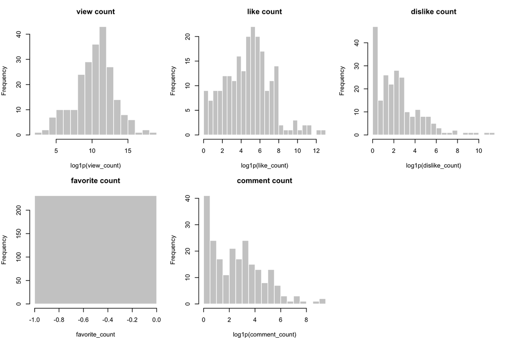

Empirical distributions. Nonconstant outcomes are shown on the log1p scale; favorite count is shown on its original scale.

```r
old_graphics_parameters <- par(mfrow = c(2, 3), mar = c(4, 4, 3, 1))
invisible(
  lapply(engagement_variables, function(variable_name) {
    values <- youtube_deid[[variable_name]]
    is_constant <- length(unique(values[!is.na(values)])) == 1L
    plotted_values <- if (is_constant) values else log1p(values)
    axis_label <- if (is_constant) {
      variable_name
    } else {
      paste0("log1p(", variable_name, ")")
    }

    hist(
      plotted_values,
      breaks = 20L,
      main = gsub("_", " ", variable_name),
      xlab = axis_label,
      col = "gray80",
      border = "white"
    )
  })
)
plot.new()
```

```r
par(old_graphics_parameters)
```

```r
outcome_decisions <- data.frame(
  original_variable = engagement_variables,
  category = c(
    "2. Transform before linear regression",
    "2. Transform before linear regression",
    "2. Transform before linear regression",
    "3. Not appropriate for linear regression",
    "2. Transform before linear regression"
  ),
  transformation = c(
    "log1p(view_count)",
    "log1p(like_count)",
    "log1p(dislike_count)",
    "None",
    "log1p(comment_count)"
  ),
  justification = c(
    "Nonnegative and strongly right-skewed with extreme values.",
    "Nonnegative and strongly right-skewed with extreme values.",
    "Right-skewed count with zeros; log1p retains zeros.",
    "All observed values are zero, so there is no outcome variation.",
    "Right-skewed count with zeros and missing values; log1p retains zeros."
  )
)
knitr::kable(outcome_decisions)
```

| original_variable | category | transformation | justification |
| --- | --- | --- | --- |
| view_count | 2. Transform before linear regression | log1p(view_count) | Nonnegative and strongly right-skewed with extreme values. |
| like_count | 2. Transform before linear regression | log1p(like_count) | Nonnegative and strongly right-skewed with extreme values. |
| dislike_count | 2. Transform before linear regression | log1p(dislike_count) | Right-skewed count with zeros; log1p retains zeros. |
| favorite_count | 3. Not appropriate for linear regression | None | All observed values are zero, so there is no outcome variation. |
| comment_count | 2. Transform before linear regression | log1p(comment_count) | Right-skewed count with zeros and missing values; log1p retains zeros. |

```r
usable_original_outcomes <- c(
  "view_count",
  "like_count",
  "dislike_count",
  "comment_count"
)
model_outcomes <- paste0("log_", usable_original_outcomes)

youtube_deid[model_outcomes] <- lapply(
  youtube_deid[usable_original_outcomes],
  log1p
)

outcome_labels <- setNames(
  paste0("log1p(", usable_original_outcomes, ")"),
  model_outcomes
)
```

The summaries and histograms show extreme right skew for views, likes, dislikes, and comments, so I use `log1p()` for those four outcomes; this transformation is defined at zero. `favorite_count` is zero for every observed commercial and therefore cannot serve as a regression outcome. Missing comments are left missing and are handled by complete-case fitting in each model.

## c.

```r
fit_characteristic_model <- function(outcome, characteristic) {
  model_formula <- reformulate(
    c(characteristic, "year"),
    response = outcome
  )
  fitted_model <- lm(model_formula, data = youtube_deid)
  coefficient_table <- summary(fitted_model)$coefficients

  data.frame(
    outcome = outcome_labels[[outcome]],
    characteristic = characteristic,
    estimate = coefficient_table[characteristic, "Estimate"],
    p_value = coefficient_table[characteristic, "Pr(>|t|)"],
    row.names = NULL
  )
}

model_results <- do.call(
  rbind,
  lapply(model_outcomes, function(outcome) {
    do.call(
      rbind,
      lapply(
        binary_characteristics,
        function(characteristic) {
          fit_characteristic_model(outcome, characteristic)
        }
      )
    )
  })
)

display_model_results <- transform(
  model_results,
  estimate = sprintf("%.4f", estimate),
  p_value = format.pval(p_value, digits = 4, eps = 0.0001)
)
knitr::kable(display_model_results)
```

| outcome | characteristic | estimate | p_value |
| --- | --- | --- | --- |
| log1p(view_count) | funny | 0.5298 | 0.20511 |
| log1p(view_count) | show_product_quickly | 0.2090 | 0.60072 |
| log1p(view_count) | patriotic | 0.1369 | 0.78392 |
| log1p(view_count) | celebrity | -0.0190 | 0.96289 |
| log1p(view_count) | danger | 0.6668 | 0.09406 |
| log1p(view_count) | animals | -0.1733 | 0.64669 |
| log1p(view_count) | use_sex | -0.2963 | 0.49052 |
| log1p(like_count) | funny | 0.3602 | 0.34006 |
| log1p(like_count) | show_product_quickly | 0.1683 | 0.64048 |
| log1p(like_count) | patriotic | 0.4931 | 0.28968 |
| log1p(like_count) | celebrity | 0.2630 | 0.47788 |
| log1p(like_count) | danger | 0.6253 | 0.08032 |
| log1p(like_count) | animals | 0.0246 | 0.94283 |
| log1p(like_count) | use_sex | -0.3250 | 0.40009 |
| log1p(dislike_count) | funny | 0.0415 | 0.89581 |
| log1p(dislike_count) | show_product_quickly | 0.2429 | 0.42097 |
| log1p(dislike_count) | patriotic | 0.6697 | 0.08564 |
| log1p(dislike_count) | celebrity | -0.2833 | 0.36163 |
| log1p(dislike_count) | danger | 0.1851 | 0.53795 |
| log1p(dislike_count) | animals | -0.0738 | 0.79742 |
| log1p(dislike_count) | use_sex | -0.3889 | 0.22928 |
| log1p(comment_count) | funny | 0.0475 | 0.87935 |
| log1p(comment_count) | show_product_quickly | 0.3460 | 0.24686 |
| log1p(comment_count) | patriotic | 0.5148 | 0.16854 |
| log1p(comment_count) | celebrity | 0.2281 | 0.45559 |
| log1p(comment_count) | danger | 0.1064 | 0.72096 |
| log1p(comment_count) | animals | -0.1918 | 0.49907 |
| log1p(comment_count) | use_sex | -0.3494 | 0.27354 |

At $\alpha=0.05$, the following table gives every statistically significant association and its direction.

```r
significant_results <- subset(model_results, p_value < 0.05)
significant_results$direction <- ifelse(
  significant_results$estimate > 0,
  "positive",
  "negative"
)

display_significant_results <- transform(
  significant_results,
  estimate = sprintf("%.4f", estimate),
  p_value = format.pval(p_value, digits = 4, eps = 0.0001)
)
knitr::kable(display_significant_results)
```

| outcome | characteristic | estimate | p_value | direction |
| --- | --- | --- | --- | --- |

At $\alpha=0.05$, none of the seven commercial characteristics is statistically significant for any of the four engagement outcomes.

```r
view_outcome <- "log_view_count"
view_results <- subset(
  model_results,
  outcome == outcome_labels[[view_outcome]]
)
positive_view_results <- subset(view_results, estimate > 0)
largest_positive_view <- positive_view_results[
  which.max(positive_view_results$estimate),
  ,
  drop = FALSE
]

knitr::kable(
  transform(
    largest_positive_view,
    estimate = sprintf("%.4f", estimate),
    p_value = format.pval(p_value, digits = 4, eps = 0.0001)
  )
)
```

|  | outcome | characteristic | estimate | p_value |
| --- | --- | --- | --- | --- |
| 5 | log1p(view_count) | danger | 0.6668 | 0.09406 |

The largest positive estimated association with the view outcome is for danger, with coefficient 0.6668. Because the response is `log1p(view_count)`, this is a difference on the transformed scale after adjusting for continuous `year`, not a raw increase in the number of views.

## d.

```r
selected_view_result <- view_results[
  which.min(view_results$p_value),
  ,
  drop = FALSE
]
selected_characteristic <- selected_view_result$characteristic

selection_evidence <- data.frame(
  view_outcome = outcome_labels[[view_outcome]],
  selected_characteristic = selected_characteristic,
  p_value = selected_view_result$p_value
)
knitr::kable(
  transform(
    selection_evidence,
    p_value = format.pval(p_value, digits = 5, eps = 0.00001)
  )
)
```

| view_outcome | selected_characteristic | p_value |
| --- | --- | --- |
| log1p(view_count) | danger | 0.094065 |

```r
matrix_data <- youtube_deid[
  , c(view_outcome, selected_characteristic, "year"),
  drop = FALSE
]
matrix_data <- matrix_data[complete.cases(matrix_data), , drop = FALSE]

design_matrix <- cbind(
  "(Intercept)" = 1,
  matrix_data[[selected_characteristic]],
  matrix_data$year
)
colnames(design_matrix) <- c(
  "(Intercept)",
  selected_characteristic,
  "year"
)
response_vector <- matrix_data[[view_outcome]]

manual_coefficients <- solve(
  t(design_matrix) %*% design_matrix
) %*% t(design_matrix) %*% response_vector

manual_coefficient_table <- data.frame(
  term = rownames(manual_coefficients),
  manual_estimate = as.numeric(manual_coefficients),
  row.names = NULL
)
knitr::kable(manual_coefficient_table, digits = 8)
```

| term | manual_estimate |
| --- | --- |
| (Intercept) | -31.391492 |
| danger | 0.666781 |
| year | 0.020656 |

The preceding calculation constructs the intercept, selected characteristic, and continuous-year columns explicitly and evaluates $(X^T X)^{-1}X^T y$ without calling `lm()`.

```r
verification_formula <- reformulate(
  c(selected_characteristic, "year"),
  response = view_outcome
)
verification_model <- lm(verification_formula, data = matrix_data)
lm_coefficients <- coef(verification_model)

coefficient_comparison <- data.frame(
  term = names(lm_coefficients),
  manual = as.numeric(manual_coefficients),
  lm = as.numeric(lm_coefficients),
  absolute_difference = abs(
    as.numeric(manual_coefficients) - as.numeric(lm_coefficients)
  ),
  row.names = NULL
)

knitr::kable(coefficient_comparison, digits = 10)
```

| term | manual | lm | absolute_difference |
| --- | --- | --- | --- |
| (Intercept) | -31.391492 | -31.391492 | 3e-10 |
| danger | 0.666781 | 0.666781 | 0e+00 |
| year | 0.020656 | 0.020656 | 0e+00 |

```r
coefficient_agreement <- isTRUE(
  all.equal(
    as.numeric(manual_coefficients),
    as.numeric(lm_coefficients),
    tolerance = 1e-8
  )
)
maximum_difference <- max(coefficient_comparison$absolute_difference)
```

The matrix calculation and `lm()` coefficients agree up to numerical precision: `all.equal()` is TRUE, and the maximum absolute difference is 3.34e-10.